# Innerdance Biofeedback — Concept for Medical Review

**Document type:** Platform description for medical and scientific reviewers, and new team members — what the system collects, computes, and reports. It does not cover the project's research objective or hypotheses; see the companion objectives & hypotheses document (internal) for that. **Version:** 3 — split into a platform description (this doc) and a separate objectives/hypotheses doc **Status:** Proof-of-concept · exploratory · not yet validated for clinical use

## The one-sentence pitch

> *A system that measures how a person's nervous system responds to sound in real time, then tracks that response against a personal baseline over weeks — using both signals to personalise the sound and reveal lasting change in autonomic resilience and flexibility.*

This document describes that system: how session data is collected, cleaned, turned into HRV metrics — the platform that enables data collection, hypothesis generation, and hypothesis testing. For *why* we're building it and what we hypothesise it will show, see the companion objectives & hypotheses document (internal).

## What the system does

A participant wears a standard chest-strap heart-rate monitor (Polar H10, ~€100), recording continuously across three phases: a **pre-session resting baseline**, the **session** itself, and a **post-session resting baseline**. The system then:

1. **Measures** how the autonomic nervous system responded to each stage of the music
2. **Compares** the response to the participant's own baseline (see *Choice of metrics — first version* below)
3. **Explains** what happened in plain language — for participant, facilitator, and reviewer

No invasive sensors are used, and every interpretive rule is cited to its source publication.

### What's actually built, today

- **Sound + ECG DB** — raw recordings stored: playlist audio and each participant's uploaded ECG/RR data
- **Data pipeline** — cleans the recording and computes HRV + acoustic features from it (see *Data pipeline* below)
- **Processed data DB** — the computed metrics, stored per session
- **User report UI** — the participant-facing HTML report shown in *Examples from real session data* below

### What might the system do in the future

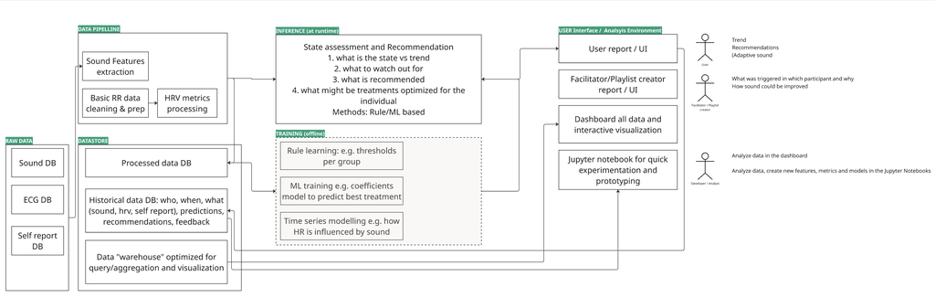

The diagram above sketches the full intended architecture — most of it does not exist yet. In this envisioned end state:

| User | Would see | Would contribute |
| --- | --- | --- |
| **Participant** | A personal report: high/low points reached, against a normal or innerdance-population reference | ECG recording, self-report |
| **Facilitator** | How each stage affected the group; which sound features drove which response | Facilitation notes, expert validation |
| **Medical practitioner** | Participant data; an acoustic-features-vs-stage heat map | Clinical interpretation, guidance on meaningful signals |
| **Developer / Analyst** | Full pipeline, notebooks, model training, dashboards | New features, model refinements, protocol design |

Beyond today's measure/compare/explain, possible future capabilities include **learning** which acoustic features drove which physiological responses, in whom, and **recommending** adjustments to the sound or session design to optimise the outcome.

## Choice of metrics — first version

| Metric | Valid when | Role |
| --- | --- | --- |
| **SD2** | Any breathing rate | Primary — stage-wise, longitudinal, and multi-participant comparisons |
| **DFA α1** | Breathing rate > 9 bpm | Primary — fractal complexity of the heartbeat (≈1.0 healthy; <0.75 more disorganised; >1.4 overly regular) |
| **RMSSD** | Most reliable at rest (pre/post baseline) | Computed throughout, but only read with confidence at pre/post baseline |
| **SD1/SD2** | Breathing rate confirmed | Short- vs long-term variability balance |
| **Heart rate / breathing rate** | Any condition / estimated from the HRV signal | Context and validity checks |

All metrics are computed from validated, open-source implementations, cross-checked against the peer-reviewed literature (see References). SDNN, used in early per-session reports, has since been dropped in favor of SD2 alone, which behaves more consistently over the shorter, non-resting windows used inside a session.

**This is a sample set, not a fixed one.** These are the metrics we currently compute and report on; we expect the set to evolve as the hypotheses being tested change — new metrics may be added, and current ones may turn out not to be the right fit.

## Examples from real session data

**1. Per-session report.** From the actual HTML report generated for a participant: metrics across the 12 stages, and the same stages' acoustic profile that produced them.

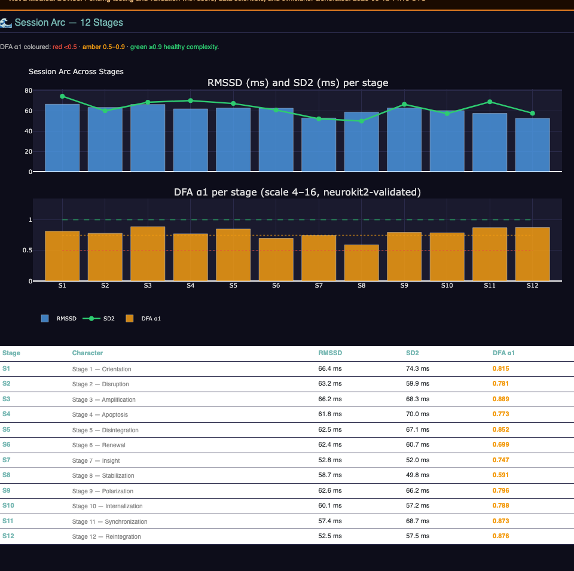

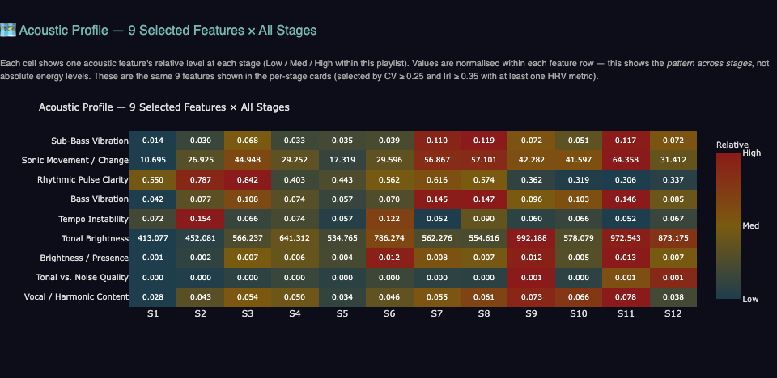

**2. Session comparison.** Across a participant's repeated sessions: resting RMSSD/SD2/DFA α1 pre vs post, the resilience arc (Stage 10 − Stage 4), and recovery % — the same metrics tracked in chronological order, which is what lets us eventually ask whether a person's baseline shifts over weeks, not just within one session.

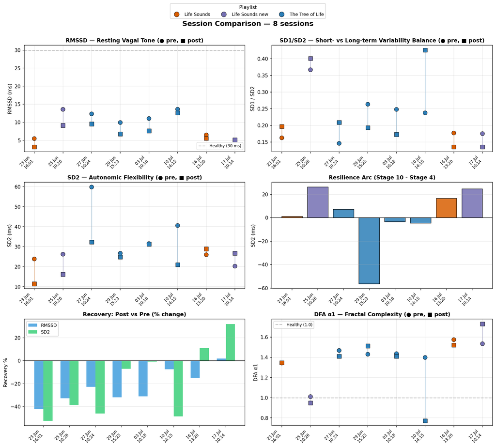

## Data pipeline

This is the pipeline structure we plan to build, so that a participant's report, a dashboard query, and a research analysis all start from identical numbers: **clean & load** the raw recording → **merge** with session metadata → **filter** to usable windows → **compute metrics** → **derive additional features** → **data-quality gate** → baseline/session plots → interpretation → medical validation.

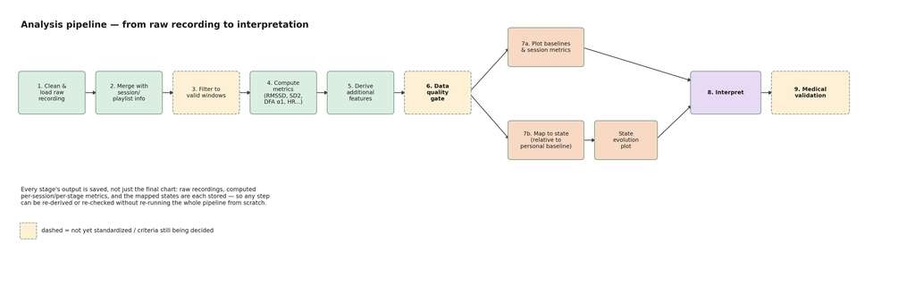

## Rules vs. models vs. adaptive personalisation

This classification approach is **Phase 0** of a longer roadmap, not the end state. We are prototyping with deterministic rules deliberately — every classification is traceable to a specific metric crossing a specific threshold from a specific paper, with no black-box inference — and intend to scale toward data-driven phases once enough per-participant and cross-participant data exists (see the project plan in the companion objectives & hypotheses document (internal)).

| Phase | Approach |
| --- | --- |
| **0 — now** | Deterministic rules with literature-cited thresholds |
| **1** | Within-person models: how each individual's ANS responds to specific acoustic features |
| **2** | Cross-participant models: pool information across individuals while preserving individual differences — important given resting HRV can vary 5–10× between people |
| **3+** | Adaptive personalisation: the system gradually learns which acoustic interventions work for which participant profiles, validated prospectively before any deployment |

Model type and validation approach for Phases 1–3+ will be defined with domain, statistical, and medical advisors — not fixed in advance.

## What we have built so far

These components are up and running, and all of them are expected to keep changing as the approach is iterated on:

- HRV processing pipeline (`hrv_core.py`)
- Acoustic feature extraction (`acoustic_core.py`)
- Interpretive rule engine (`hrv_rules.py`) — draft; not yet wired into report generation, and awaiting medical review
- Per-session report, longitudinal trend view (examples above)
- Database (Supabase)
- React upload UI — handles ECG upload + playback sync

**Not yet started:** data-quality gate, model/training layer.

## Data currently in the database

|  | Count |
| --- | --- |
| Total user accounts / sessions logged | 145 / 149 |
| Sessions with an uploaded HRV recording | 41 |
| — real participants (test/demo excluded), on one of the 3 main playlists | 29 |
| — across how many real user accounts | 19 |
| Unique real participants (after resolving account fragmentation by hand) | 15 |

By playlist: Life Sounds 12 sessions · The Tree of Life 10 sessions · Life Sounds new 7 sessions.

## References

- Task Force of the ESC/NASPE (1996). Heart rate variability: standards of measurement, physiological interpretation and clinical use. *Circulation* 93:1043–1065. [doi:10.1161/01.CIR.93.5.1043](https://doi.org/10.1161/01.CIR.93.5.1043)
- Shaffer & Ginsberg (2017). An overview of heart rate variability metrics and norms. *Front. Public Health* 5:258. [doi:10.3389/fpubh.2017.00258](https://doi.org/10.3389/fpubh.2017.00258)
- Peng et al. (1995). Quantification of scaling exponents and crossover phenomena in nonstationary heartbeat time series. *Chaos* 5(1):82–87. [doi:10.1063/1.166141](https://doi.org/10.1063/1.166141)
- (2022). Root mean square of successive differences is not a valid measure of parasympathetic reactivity during slow deep breathing. *Am. J. Physiol. Regul. Integr. Comp. Physiol.* [doi:10.1152/ajpregu.00272.2022](https://doi.org/10.1152/ajpregu.00272.2022)
- Lehrer & Gevirtz (2014). Heart rate variability biofeedback: how and why does it work? *Front. Psychol.* 5:756. [doi:10.3389/fpsyg.2014.00756](https://doi.org/10.3389/fpsyg.2014.00756)
- Nunan, Sandercock & Brodie (2010). A quantitative systematic review of normal values for short-term heart rate variability in healthy adults. *Pacing Clin. Electrophysiol.* 33:1407–1417. [doi:10.1111/j.1540-8159.2010.02841.x](https://doi.org/10.1111/j.1540-8159.2010.02841.x)

*Innerdance Biofeedback POC — internal research document* *Not for clinical use or distribution without author approval*